# capstone_Project

According to The World Health Organization (WHO) close to 800 000 people die by suicide every year. Furthermore, for each suicide, there are more than 20 suicide attempts. Suicides and suicide attempts have a ripple effect that impacts on families, friends, colleagues, communities and societies. Suicides are preventable. Much can be done to prevent suicide at individual, community and national levels. So, comes my intuition to inspect the similarities between the nations in committing suicides to give some indicator on how to prevent them

```python
# loading the libraries
import pandas as pd
import matplotlib.pyplot as plt
import seaborn as sns
from collections import Counter
%matplotlib inline
```

```python
# Plot settings
plt.style.use("ggplot")
plt.rcParams["figure.figsize"] = [12, 6]
plt.rcParams["figure.dpi"] = 150
```

```python
#  Data Exploration
try:
    data = pd.read_csv("master.csv")
   #data.drop(['population'], axis = 1, inplace = True)
    print("Wholesale susicde dataset has {} samples with {} features each.".format(*data.shape))
except:
    print("Dataset could not be loaded. Is the dataset missing?")
data.head()
```

```
Wholesale susicde dataset has 27820 samples with 12 features each.
```

|  | country | year | sex | age | suicides_no | population | suicides/100k pop | country-year | HDI for year | gdp_for_year ($) | gdp_per_capita ($) | generation |
| --- | --- | --- | --- | --- | --- | --- | --- | --- | --- | --- | --- | --- |
| 0 | Albania | 1987 | male | 15-24 years | 21 | 312900 | 6.71 | Albania1987 | NaN | 2,156,624,900 | 796 | Generation X |
| 1 | Albania | 1987 | male | 35-54 years | 16 | 308000 | 5.19 | Albania1987 | NaN | 2,156,624,900 | 796 | Silent |
| 2 | Albania | 1987 | female | 15-24 years | 14 | 289700 | 4.83 | Albania1987 | NaN | 2,156,624,900 | 796 | Generation X |
| 3 | Albania | 1987 | male | 75+ years | 1 | 21800 | 4.59 | Albania1987 | NaN | 2,156,624,900 | 796 | G.I. Generation |
| 4 | Albania | 1987 | male | 25-34 years | 9 | 274300 | 3.28 | Albania1987 | NaN | 2,156,624,900 | 796 | Boomers |

```python
display(data.describe())
```

|  | year | suicides_no | population | suicides/100k pop | HDI for year | gdp_per_capita ($) |
| --- | --- | --- | --- | --- | --- | --- |
| count | 27820.000000 | 27820.000000 | 2.782000e+04 | 27820.000000 | 8364.000000 | 27820.000000 |
| mean | 2001.258375 | 242.574407 | 1.844794e+06 | 12.816097 | 0.776601 | 16866.464414 |
| std | 8.469055 | 902.047917 | 3.911779e+06 | 18.961511 | 0.093367 | 18887.576472 |
| min | 1985.000000 | 0.000000 | 2.780000e+02 | 0.000000 | 0.483000 | 251.000000 |
| 25% | 1995.000000 | 3.000000 | 9.749850e+04 | 0.920000 | 0.713000 | 3447.000000 |
| 50% | 2002.000000 | 25.000000 | 4.301500e+05 | 5.990000 | 0.779000 | 9372.000000 |
| 75% | 2008.000000 | 131.000000 | 1.486143e+06 | 16.620000 | 0.855000 | 24874.000000 |
| max | 2016.000000 | 22338.000000 | 4.380521e+07 | 224.970000 | 0.944000 | 126352.000000 |

```python
# Number of unique countries
print("Number of unique countries {}".format(len(pd.unique(data["country"]))))
# occurence per country
print("Number of occurence per country :")
print(Counter(data["country"]).most_common()[:20])
```

```
Number of unique countries 101
Number of occurence per country :
[('Austria', 382), ('Iceland', 382), ('Mauritius', 382), ('Netherlands', 382), ('Argentina', 372), ('Belgium', 372), ('Brazil', 372), ('Chile', 372), ('Colombia', 372), ('Ecuador', 372), ('Greece', 372), ('Israel', 372), ('Italy', 372), ('Japan', 372), ('Luxembourg', 372), ('Malta', 372), ('Mexico',…
```

It seems that The dataset does not contain the same number of occurence for each country. This is mainly because the data is not available for every year for each country.

```python
print ("The data covers the period from {} to {}".format(min(data["year"]), max(data["year"])))
```

```
The data covers the period from 1985 to 2016
```

Here we are to get some statistics about the occurnce of suicde between diffrent varibles

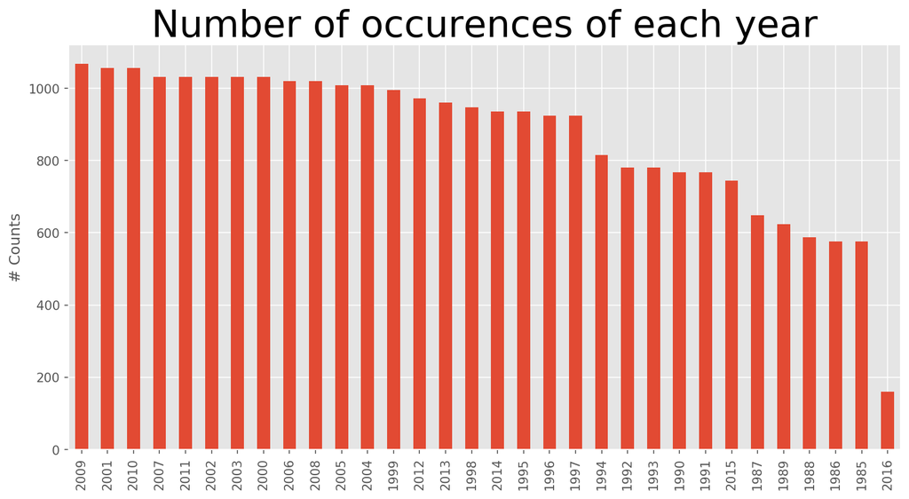

```python
data["year"].value_counts().plot.bar()
plt.title("Number of occurences of each year", size = 30)
plt.ylabel("# Counts");
```

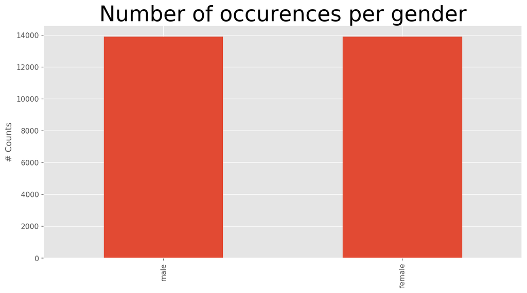

```python
data["sex"].value_counts().plot.bar()
plt.title("Number of occurences per gender", size = 30)
plt.ylabel("# Counts");
```

- I need to explore how the sucide rates has evloved through the years so i need to get some some correlation between data to get some insights

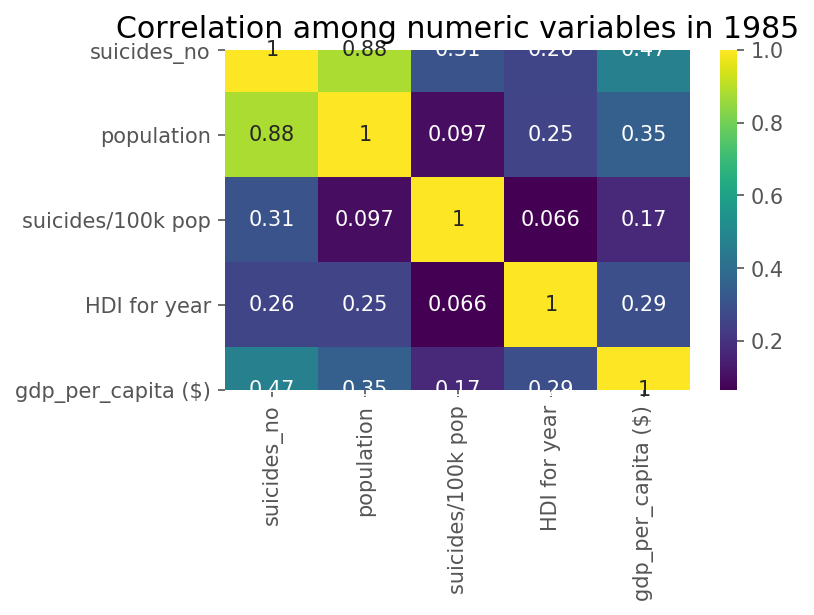

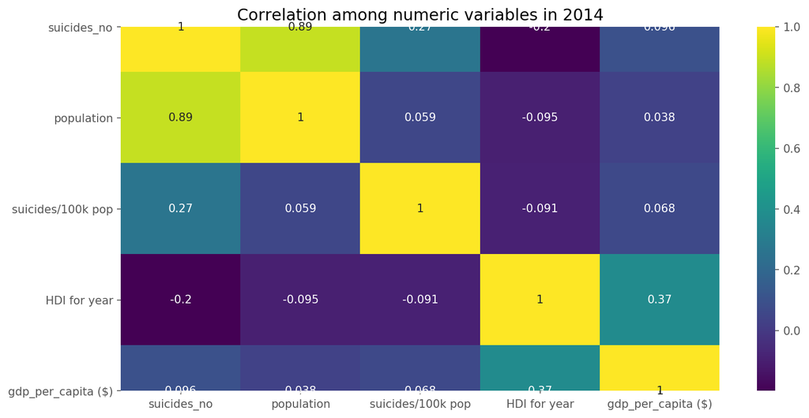

```python
def correlation_plot(data, year):
    df = data[data["year"] == year].drop(columns = "year").copy()
    sns.heatmap(
    df.groupby("country").agg("sum").corr(), cmap = "viridis", annot = True)
    plt.title(f"Correlation among numeric variables in {year}")
    plt.show();
plt.figure(figsize= (5, 3))
correlation_plot(data, 1985)
correlation_plot(data, 2014)
```

### Link between the evolution of suicide and the evolution of other variables

```python
data["year"] = pd.to_datetime(data["year"], format = "%Y")
```

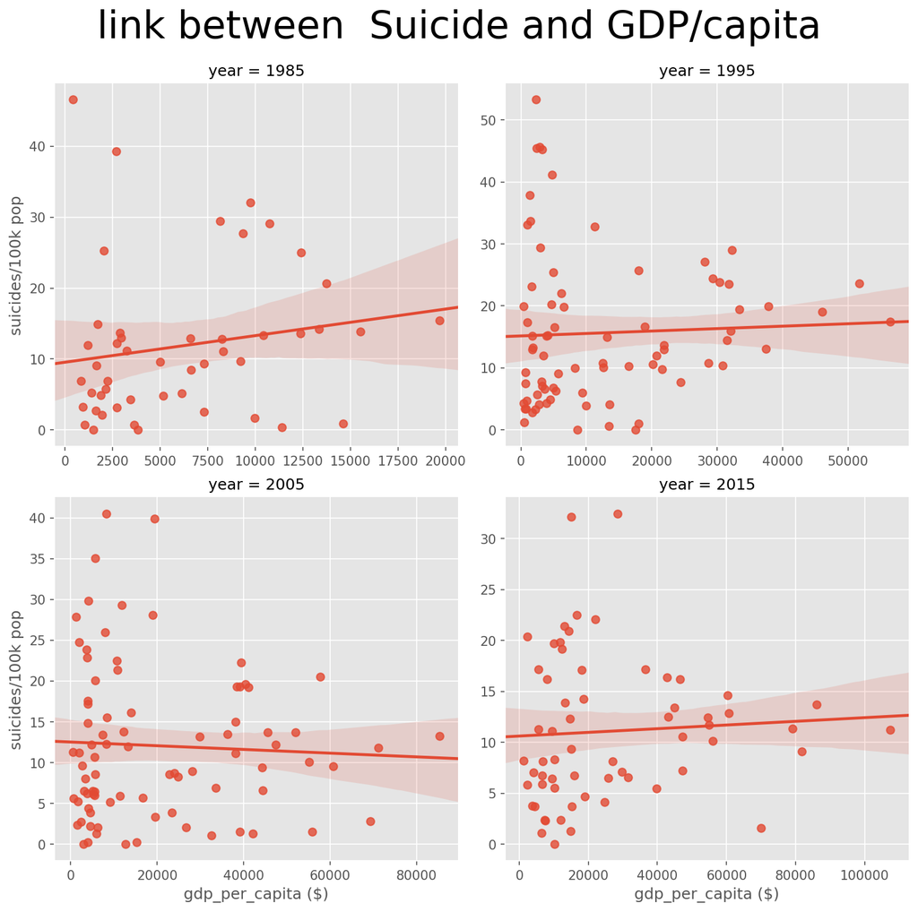

```python
def plot_scatter_links(x:str, y:str, years:list,
                       agg_fun = "sum", n_col = None):

    df = data[data["year"].isin(years)]

    df = df.groupby(["year", "country"]).agg(agg_fun).reset_index()
    df["year"] = df["year"].dt.year.astype("object")
    sns.lmplot(x, y, scatter = True, fit_reg= True,
               data = df, col = "year", col_wrap = n_col, sharex = False, sharey = False)

plot_scatter_links(x = "gdp_per_capita ($)", y = "suicides/100k pop",
                   years = ["1985","1995", "2005", "2015"], n_col= 2, agg_fun= "mean")
plt.subplots_adjust(top=.9)
plt.suptitle("link between  Suicide and GDP/capita", size = 30);
```

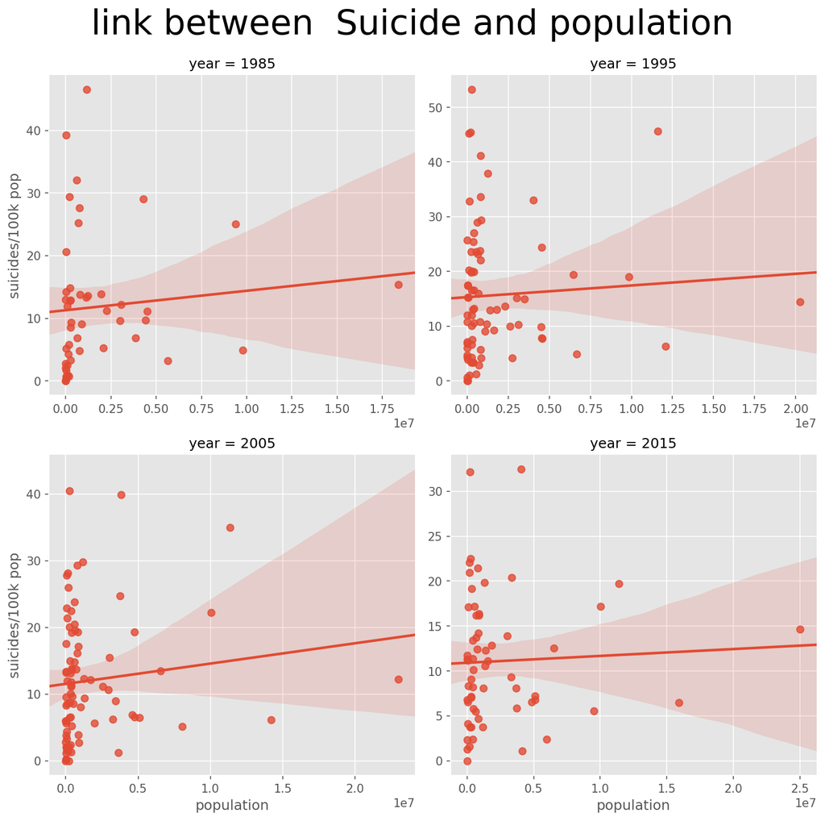

```python
plot_scatter_links(x = "population", y = "suicides/100k pop",
                   years = ["1985","1995", "2005", "2015"], n_col= 2, agg_fun= "mean")
plt.subplots_adjust(top=.9)
plt.suptitle("link between  Suicide and population", size = 30);
```

# Clustering

I'm adding a new column called occurence which gives tha value 1 to every row so that whenever we group and sum the numeric data we can come back to the original data by dividing it.

```python
data["occurence"] = 1
data["part_generation"] = 0
new_data = data.groupby(["year", "country"]).agg("sum").reset_index()

new_data["year"] = new_data["year"].dt.year
# here i drop the poplution
new_data.drop(['population'], axis = 1, inplace = True)
print("Wholesale new_Data dataset has {} samples with {} features each.".format(*new_data.shape))
new_data.head()
```

```
Wholesale new_Data dataset has 2321 samples with 8 features each.
```

|  | year | country | suicides_no | suicides/100k pop | HDI for year | gdp_per_capita ($) | occurence | part_generation |
| --- | --- | --- | --- | --- | --- | --- | --- | --- |
| 0 | 1985 | Antigua and Barbuda | 0 | 0.00 | 0.000 | 46200 | 12 | 0 |
| 1 | 1985 | Argentina | 1988 | 134.47 | 8.328 | 39168 | 12 | 0 |
| 2 | 1985 | Australia | 1861 | 163.41 | 0.000 | 148488 | 12 | 0 |
| 3 | 1985 | Austria | 2091 | 384.81 | 9.168 | 117108 | 12 | 0 |
| 4 | 1985 | Bahamas | 1 | 4.76 | 0.000 | 136716 | 12 | 0 |

#### Scaling the dataset

```python
from sklearn.preprocessing import StandardScaler
X = StandardScaler()
X = X.fit_transform(new_data.drop(["year", "country"], axis = 1))
selected_columns = ['suicides_no', 'suicides/100k pop', 'HDI for year',
        'gdp_per_capita ($)', 'part_generation','occurence']

new_data[selected_columns] = X
new_data.head()
```

|  | year | country | suicides_no | suicides/100k pop | HDI for year | gdp_per_capita ($) | occurence | part_generation |
| --- | --- | --- | --- | --- | --- | --- | --- | --- |
| 0 | 1985 | Antigua and Barbuda | -0.410885 | -1.313957 | -0.648461 | -0.689247 | 0.0 | 0.083315 |
| 1 | 1985 | Argentina | -0.129948 | -0.163769 | 1.281230 | -0.720323 | 0.0 | 0.083315 |
| 2 | 1985 | Australia | -0.147895 | 0.083769 | -0.648461 | -0.237212 | 0.0 | 0.083315 |
| 3 | 1985 | Austria | -0.115392 | 1.977512 | 1.475867 | -0.375887 | 0.0 | 0.083315 |
| 4 | 1985 | Bahamas | -0.410744 | -1.273243 | -0.648461 | -0.289235 | 0.0 | 0.083315 |

#### Applying Clustering

Here i'll exmaine the best algorithm to perform clustring

## K-Means VS GaussianMixture

## 1985 data

```python
from sklearn.cluster import KMeans

# prepraing training data
x = new_data[new_data["year"] == 1985].drop(["year", "suicides_no"],
                                                      axis = 1).set_index("country")
```

##### K-Means

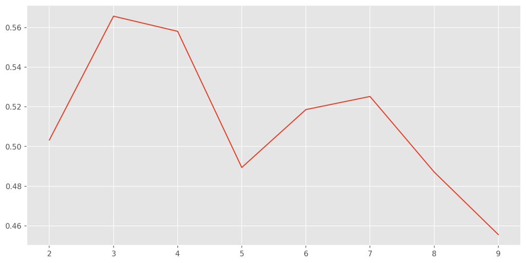

```python
from sklearn.metrics import silhouette_score
inertia =[]
for k in range(2, 10):
    kmeans = KMeans(n_clusters=k, random_state=0).fit(x)
    preds = kmeans.predict(x)
    inertia.append(silhouette_score(x, preds))
ax = plt.plot(range(2,10),inertia)
```

##### GaussianMixture

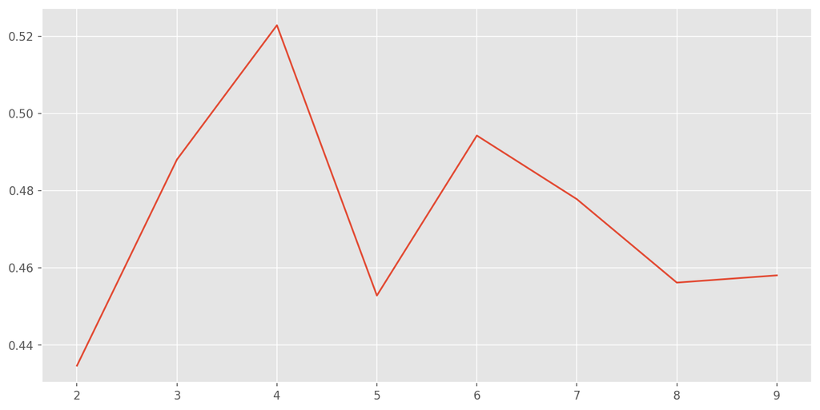

```python
from sklearn.mixture import GaussianMixture
inertia =[]
for k in range(2, 10):
    clusterer = GaussianMixture(n_components = k)
    clusterer.fit(x)
    preds = clusterer.predict(x)
    inertia.append(silhouette_score(x, preds))

ax = plt.plot(range(2,10),inertia)
```

## 2015 data

```python
# prepraing training data
x_2015 = new_data[new_data["year"] == 2015].drop(["year", "suicides_no"],
                                                      axis = 1).set_index("country")
```

##### K-Means

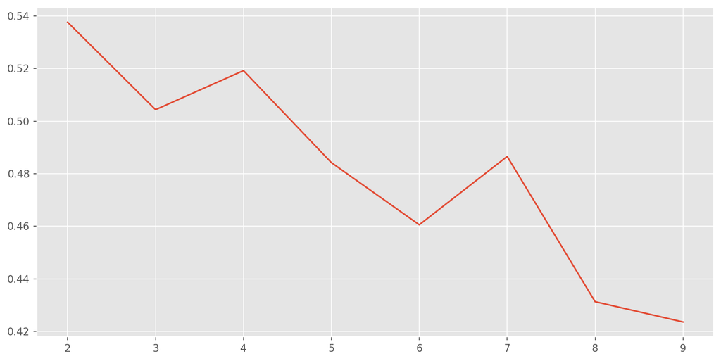

```python
from sklearn.metrics import silhouette_score
inertia =[]
for k in range(2, 10):
    kmeans = KMeans(n_clusters=k, random_state=0).fit(x_2015)
    preds = kmeans.predict(x_2015)
    inertia.append(silhouette_score(x_2015, preds))
ax = plt.plot(range(2,10),inertia)
```

##### GaussianMixture

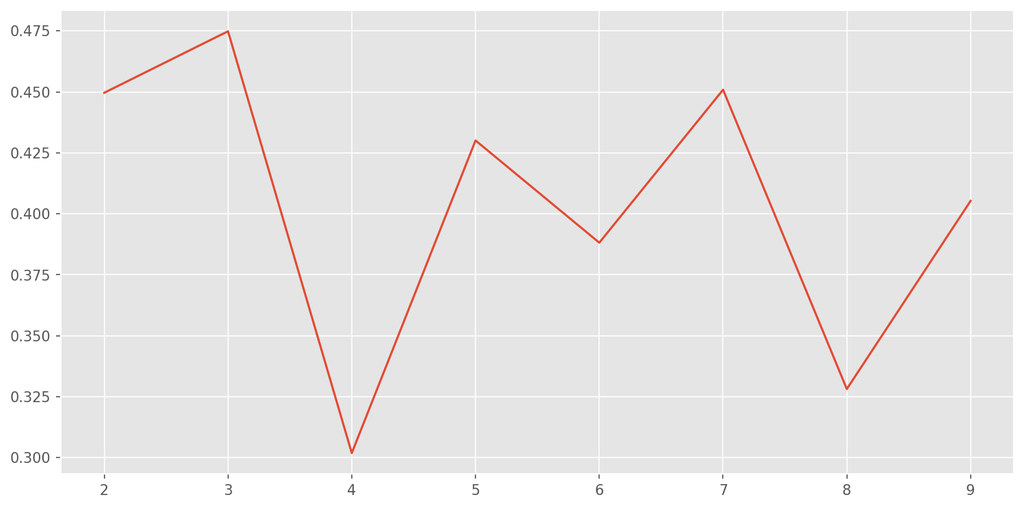

```python
from sklearn.mixture import GaussianMixture
inertia =[]
for k in range(2, 10):
    clusterer = GaussianMixture(n_components = k)
    clusterer.fit(x_2015)
    preds = clusterer.predict(x_2015)
    inertia.append(silhouette_score(x_2015, preds))

ax = plt.plot(range(2,10),inertia)
```

### Clusters Viualization

#### 1985 data

```python
kmeans_1985 = KMeans(n_clusters=3)

predictions_1985 = kmeans_1985.fit_predict(x)

pd.value_counts(kmeans_1985.labels_, sort = False)
```

```
0    30
1     9
2     9
dtype: int64
```

```python
k = 3
clusters = []
for j in range(0,k):
    clusters.append([])
for i in range(0,x.shape[0]):
    clusters[kmeans_1985.labels_[i]].append(x.index[i])

for j in range(0,k):
    print(30*"-", "\n")
    print( j, clusters[j])
```

```
------------------------------

0 ['Argentina', 'Bahrain', 'Barbados', 'Brazil', 'Canada', 'Chile', 'Colombia', 'Costa Rica', 'Ecuador', 'Greece', 'Iceland', 'Ireland', 'Israel', 'Italy', 'Jamaica', 'Kuwait', 'Malta', 'Mauritius', 'Mexico', 'Netherlands', 'New Zealand', 'Panama', 'Paraguay', 'Portugal', 'Spain', 'Thailand', 'Trini…
------------------------------

1 ['Austria', 'Belgium', 'Bulgaria', 'France', 'Japan', 'Luxembourg', 'Singapore', 'Sri Lanka', 'Suriname']
------------------------------

2 ['Antigua and Barbuda', 'Australia', 'Bahamas', 'Dominica', 'Grenada', 'Puerto Rico', 'Republic of Korea', 'Saint Vincent and Grenadines', 'Seychelles']
```

#### 2015 data

```python
kmeans_2015 = KMeans(init= "k-means++", n_clusters= 2, n_init = 20)
predictions_2015 = kmeans_2015.fit(x_2015)
k = 2
clusters = []
for j in range(0,k):
    clusters.append([])
for i in range(0,x_2015.shape[0]):
    clusters[kmeans_2015.labels_[i]].append(x_2015.index[i])

for j in range(0,k):
    print(30*"-", "\n")
    print( j, clusters[j])
```

```
------------------------------

0 ['Australia', 'Austria', 'Belgium', 'Denmark', 'Finland', 'Germany', 'Iceland', 'Israel', 'Japan', 'Luxembourg', 'Netherlands', 'Norway', 'Qatar', 'Singapore', 'Sweden', 'Switzerland', 'United Kingdom', 'United States']
------------------------------

1 ['Antigua and Barbuda', 'Argentina', 'Armenia', 'Belize', 'Brazil', 'Chile', 'Colombia', 'Croatia', 'Cuba', 'Cyprus', 'Czech Republic', 'Ecuador', 'Estonia', 'Georgia', 'Greece', 'Grenada', 'Guatemala', 'Hungary', 'Italy', 'Kazakhstan', 'Kyrgyzstan', 'Latvia', 'Lithuania', 'Malta', 'Mauritius', 'M…
```

## Model Evaluation

Here i will introduce the poplution to the data set to evaluate my solution

```python
eval_data = data.groupby(["year", "country"]).agg("sum").reset_index()

eval_data["year"] = eval_data["year"].dt.year
print("Wholesale eval_data dataset has {} samples with {} features each.".format(*eval_data.shape))
eval_data.head()
```

```
Wholesale eval_data dataset has 2321 samples with 9 features each.
```

|  | year | country | suicides_no | population | suicides/100k pop | HDI for year | gdp_per_capita ($) | occurence | part_generation |
| --- | --- | --- | --- | --- | --- | --- | --- | --- | --- |
| 0 | 1985 | Antigua and Barbuda | 0 | 62574 | 0.00 | 0.000 | 46200 | 12 | 0 |
| 1 | 1985 | Argentina | 1988 | 27090800 | 134.47 | 8.328 | 39168 | 12 | 0 |
| 2 | 1985 | Australia | 1861 | 14562500 | 163.41 | 0.000 | 148488 | 12 | 0 |
| 3 | 1985 | Austria | 2091 | 7110115 | 384.81 | 9.168 | 117108 | 12 | 0 |
| 4 | 1985 | Bahamas | 1 | 203700 | 4.76 | 0.000 | 136716 | 12 | 0 |

```python
X = StandardScaler()
X = X.fit_transform(eval_data.drop(["year", "country"], axis = 1))
selected_columns = ['suicides_no', 'suicides/100k pop', 'HDI for year',
        'gdp_per_capita ($)', 'part_generation','occurence','population']

eval_data[selected_columns] = X
eval_data.head()
```

|  | year | country | suicides_no | population | suicides/100k pop | HDI for year | gdp_per_capita ($) | occurence | part_generation |
| --- | --- | --- | --- | --- | --- | --- | --- | --- | --- |
| 0 | 1985 | Antigua and Barbuda | -0.410885 | -0.648461 | -0.689247 | 0.0 | -0.529191 | 0.083315 | -1.313957 |
| 1 | 1985 | Argentina | -0.129948 | 1.281230 | -0.720323 | 0.0 | 0.119490 | 0.083315 | -0.163769 |
| 2 | 1985 | Australia | -0.147895 | -0.648461 | -0.237212 | 0.0 | -0.181191 | 0.083315 | 0.083769 |
| 3 | 1985 | Austria | -0.115392 | 1.475867 | -0.375887 | 0.0 | -0.360049 | 0.083315 | 1.977512 |
| 4 | 1985 | Bahamas | -0.410744 | -0.648461 | -0.289235 | 0.0 | -0.525804 | 0.083315 | -1.273243 |

```python
x_eval_1985 = eval_data[eval_data["year"] == 1985].drop(["year", "suicides_no"],
                                                      axis = 1).set_index("country")
```

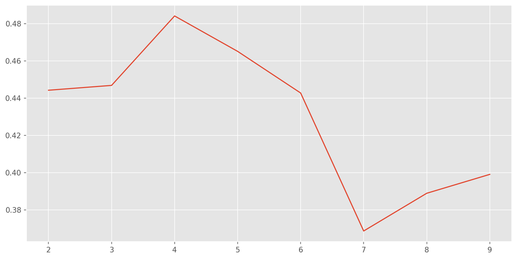

```python
inertia =[]
for k in range(2, 10):
    kmeans = KMeans(n_clusters=k, random_state=0).fit(x_eval_1985)
    preds = kmeans.predict(x_eval_1985)
    inertia.append(silhouette_score(x_eval_1985, preds))
ax = plt.plot(range(2,10),inertia)
```